####*Objective 7. Perform differential expression analysis*

Packages used in this notebook: `limma`, `RColorBrewer`. First verify that they are installed and loaded.

Set the directory where you want the results to be stored (this assumes that you have a folder called *RNAseq* on your desktop, with a subfolder called *Results*).

```r
## if you ARE using an R notebook (if not the comment out this line):
knitr::opts_knit$set(root.dir = "~/Desktop/RNAseq/Results/")

## if you ARE NOT using an R notebook (un-comment this line):
#setwd("~/Desktop/RNAseq/Results/")
```

Since clustering suggested there may be differences in sample groups, here we will be formally testing whether genes are differentially expressed between the groups.  
First we need to do a little set-up which involves creating design and contrast matrices.

Let’s make a design matrix with groups to be compared (this makes dummy variables for each sample indicating which group they belong to). We can do this with the `model.matrix()` function from the `stats` package.

```r
?model.matrix
grps
```

```
[1] LP    ML    Basal Basal ML    LP    Basal ML    LP
Levels: Basal LP ML
```

```r
design <- model.matrix(~0 + grps)
design
```

```
  grpsBasal grpsLP grpsML
1         0      1      0
2         0      0      1
3         1      0      0
4         1      0      0
5         0      0      1
6         0      1      0
7         1      0      0
8         0      0      1
9         0      1      0
attr(,"assign")
[1] 1 1 1
attr(,"contrasts")
attr(,"contrasts")$grps
[1] "contr.treatment"
```

Now we’ll just relable the columns.

```r
colnames(design) <- gsub("grps", "", colnames(design))
design
```

```
  Basal LP ML
1     0  1  0
2     0  0  1
3     1  0  0
4     1  0  0
5     0  0  1
6     0  1  0
7     1  0  0
8     0  0  1
9     0  1  0
attr(,"assign")
[1] 1 1 1
attr(,"contrasts")
attr(,"contrasts")$grps
[1] "contr.treatment"
```

We also need a contrast matrix to indicate which groups to compare to each other (reference group has a value of 1, comparison group has a value of -1). The `makeContrasts()` function is from the `limma` package.

```r
?makeContrasts

contrast <- makeContrasts(
   BasalvsLP = Basal - LP,
   BasalvsML = Basal - ML,
   LPvsML = LP - ML,
   levels = colnames(design))
contrast
```

```
       Contrasts
Levels  BasalvsLP BasalvsML LPvsML
  Basal         1         1      0
  LP           -1         0      1
  ML            0        -1     -1
```

Now we use `voom()` from `limma` to combine log2(CPM) values from the filtered, normalized data with the design matrix.

```r
?voom

dge_voom <- voom(dge_sub_norm, design)
dge_voom
```

```
An object of class "EList"
$targets
```

|  | files | group | lib.size | norm.factors |
| --- | --- | --- | --- | --- |
| GSM1545535_10_6_5_11 | GSM1545535_10_6_5_11.txt | LP | 29442523 | 0.8959157 |
| GSM1545536_9_6_5_11 | GSM1545536_9_6_5_11.txt | ML | 36569701 | 1.0349283 |
| GSM1545538_purep53 | GSM1545538_purep53.txt | Basal | 59665702 | 1.0438217 |
| GSM1545539_JMS8-2 | GSM1545539_JMS8-2.txt | Basal | 53442147 | 1.0403655 |
| GSM1545540_JMS8-3 | GSM1545540_JMS8-3.txt | ML | 78263293 | 1.0325649 |
| GSM1545541_JMS8-4 | GSM1545541_JMS8-4.txt | LP | 55825537 | 0.9224669 |
| GSM1545542_JMS8-5 | GSM1545542_JMS8-5.txt | Basal | 54176051 | 0.9834755 |
| GSM1545544_JMS9-P7c | GSM1545544_JMS9-P7c.txt | ML | 23069044 | 1.0824912 |
| GSM1545545_JMS9-P8c | GSM1545545_JMS9-P8c.txt | LP | 19547421 | 0.9793867 |

```
$E
        Samples
Tags     GSM1545535_10_6_5_11 GSM1545536_9_6_5_11 GSM1545538_purep53 GSM1545539_JMS8-2 GSM1545540_JMS8-3
  497097            -4.294867           -3.870649           2.521130          3.300384         -4.482909
  27395              3.873387            4.398945           4.519550          4.569002          4.321222
  18777              4.706072            5.557711           5.398946          5.169612          5.626175
  21399              4.782839            4.740376           5.372925          5.129302          4.846407
  58175              3.941945            3.293252          -1.769547         -1.881925          2.991666
        Samples
Tags     GSM1545541_JMS8-4 GSM1545542_JMS8-5 GSM1545544_JMS9-P7c GSM1545545_JMS9-P8c
  497097         -3.995498          3.305159           -3.205958           -5.288906
  27395           3.784924          3.917255            4.344019            4.131054
  18777           5.080172          5.078439            5.755781            5.148846
  21399           4.942401          5.156669            5.035310            4.986054
  58175           3.355756         -2.115727            3.140999            3.521665
14160 more rows ...

$weights
           [,1]       [,2]      [,3]      [,4]      [,5]       [,6]      [,7]       [,8]       [,9]
[1,]  0.9685941  0.9724948 15.470258 14.585074  1.352363  0.9685941 14.694030  0.9685941  0.9685941
[2,] 14.7375573 18.9216314 22.487147 21.721877 24.265649 19.9461321 21.815449 15.1473890 11.6964349
[3,] 20.6180453 24.9577482 25.665667 25.300870 25.882516 24.7660979 25.350790 22.1991076 17.3187657
[4,] 20.2154651 21.6812939 25.672245 25.310923 25.748413 24.5057896 25.360868 18.0882671 16.8998629
[5,] 13.0081920 12.2475722  2.241045  2.122259 18.258371 18.1295533  2.136545  9.4244991 10.2907252
14160 more rows ...

$design
  Basal LP ML
1     0  1  0
2     0  0  1
3     1  0  0
4     1  0  0
5     0  0  1
6     0  1  0
7     1  0  0
8     0  0  1
9     0  1  0
attr(,"assign")
[1] 1 1 1
attr(,"contrasts")
attr(,"contrasts")$grps
[1] "contr.treatment"
```

Now we can put this into a linear model where the groups are compared separately for each gene using `lmFit()` from `limma`.

```r
?lmFit
dge_fit <- lmFit(dge_voom, design)
```

Next we’ll use the contrast matrix created above so we can compare the groups to each other (this is what we care about the most).

```r
?contrasts.fit
grp_fit <- contrasts.fit(dge_fit, contrasts=contrast)
```

Notice that these grp_fit coefficients are equal to the differences between the coefficients from the dge_fit model above.

```r
head(dge_fit$coefficients)
```

```
           Basal        LP        ML
497097  3.032557 -4.526424 -3.926573
27395   4.336812  3.900323  4.352352
18777   5.216452  4.976128  5.642172
21399   5.220316  4.902027  4.863471
58175  -1.920031  3.581026  3.119415
108664  5.136674  5.962631  6.181856
```

```r
head(grp_fit$coefficients)
```

```
        Contrasts
          BasalvsLP   BasalvsML      LPvsML
  497097  7.5589808  6.95912966 -0.59985117
  27395   0.4364894 -0.01553972 -0.45202914
  18777   0.2403241 -0.42572053 -0.66604467
  21399   0.3182895  0.35684493  0.03855541
  58175  -5.5010571 -5.03944656  0.46161051
  108664 -0.8259577 -1.04518261 -0.21922493
```

Finally, we use an empirical Bayes method to use information across all genes- this should make the residual variances independent of the expression levels. The `eBayes()` function is also from `limma`.

```r
?eBayes
efit <- eBayes(grp_fit)
efit
```

```
An object of class "MArrayLM"
$coefficients
        Contrasts
          BasalvsLP   BasalvsML      LPvsML
  497097  7.5589808  6.95912966 -0.59985117
  27395   0.4364894 -0.01553972 -0.45202914
  18777   0.2403241 -0.42572053 -0.66604467
  21399   0.3182895  0.35684493  0.03855541
  58175  -5.5010571 -5.03944656  0.46161051
14160 more rows ...

$stdev.unscaled
        Contrasts
         BasalvsLP BasalvsML    LPvsML
  497097 0.6053826 0.5709461 0.8048442
  27395  0.1915903 0.1796896 0.1967319
  18777  0.1704447 0.1636900 0.1721612
  21399  0.1712507 0.1684090 0.1774576
  58175  0.4218859 0.4229578 0.2217691
14160 more rows ...

$sigma
[1] 1.1544970 1.0588320 0.8319412 0.6092177 0.7592627
14160 more elements ...

$df.residual
[1] 6 6 6 6 6
14160 more elements ...

$cov.coefficients
           Contrasts
Contrasts    BasalvsLP BasalvsML     LPvsML
  BasalvsLP  0.6666667 0.3333333 -0.3333333
  BasalvsML  0.3333333 0.6666667  0.3333333
  LPvsML    -0.3333333 0.3333333  0.6666667

$rank
[1] 3

$Amean
```

[output cut: 74 more lines]

```
         BasalvsLP BasalvsML    LPvsML
  497097  6.802719  6.734484 -5.390020
  27395  -5.329357 -7.669386 -4.685735
  18777  -6.436191 -4.279996 -1.178157
  21399  -5.109742 -4.558131 -7.017305
  58175   9.687759  8.960463 -4.210856
14160 more rows ...

$F
[1]  88.842165   3.428844  10.352668   4.650473 151.613499
14160 more elements ...

$F.p.value
[1] 3.897806e-07 7.304284e-02 3.584932e-03 3.701715e-02 2.939364e-08
14160 more elements ...
```

Just to make sure the eBayes method worked, we can plot the average expression vs. the residual variance (there should be no correlation).

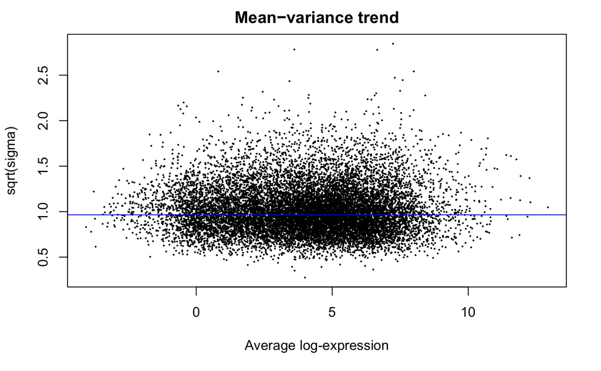

```r
?plotSA
plotSA(efit, main="Mean−variance trend")
```

**Question:** Would you exclude any genes based on this plot?

Now we can find out how many genes are significantly different between the groups.

```r
?decideTests
summary(decideTests(efit))
```

```
       BasalvsLP BasalvsML LPvsML
Down        4019      4312   2490
NotSig      5859      5595   9639
Up          4287      4258   2036
```

And we can find the most significant genes (e.g. top 10). The F statistic reflects the magnitude of the overall group differences, and the adjusted p-value corrects for multiple comparisons. It is possible to look at overall statistics for the three contrasts, but we will take a look at the top 10 genes for each contrast one at a time (i.e. Basal vs. LP, Basal vs. ML, LP vs. ML) by using the coef argument.

```r
?topTable

## look at top 10 overall by F statistics/p-values
topTableF(efit, number=10)
```

|  | BasalvsLP | BasalvsML | LPvsML | AveExpr | F | P.Value | adj.P.Val |
| --- | --- | --- | --- | --- | --- | --- | --- |
| 12521 | -4.086791 | -4.647206 | -0.56041468 | 7.069340 | 1001.5648 | 2.450684e-12 | 3.471394e-08 |
| 20661 | -3.816069 | -4.939459 | -1.12339022 | 6.704161 | 773.4869 | 8.967276e-12 | 5.261742e-08 |
| 22249 | -4.342706 | -4.550390 | -0.20768402 | 5.662874 | 740.6896 | 1.114382e-11 | 5.261742e-08 |
| 21804 | 5.193024 | 6.139285 | 0.94626133 | 3.747632 | 635.4652 | 2.401879e-11 | 5.800943e-08 |
| 16324 | -4.711261 | -4.411284 | 0.29997710 | 6.460624 | 614.7215 | 2.836216e-11 | 5.800943e-08 |
| 218518 | -5.207554 | -4.795121 | 0.41243322 | 4.929711 | 592.4517 | 3.411759e-11 | 5.800943e-08 |
| 16669 | -4.568327 | -5.515615 | -0.94728815 | 9.870235 | 553.1212 | 4.811516e-11 | 5.800943e-08 |
| 67451 | -5.653721 | -5.076757 | 0.57696402 | 4.418872 | 546.2021 | 5.124279e-11 | 5.800943e-08 |
| 66871 | 4.676928 | 4.358100 | -0.31882808 | 4.312084 | 543.6894 | 5.243848e-11 | 5.800943e-08 |
| 53624 | -5.366019 | -5.317994 | 0.04802471 | 6.295139 | 542.5784 | 5.297780e-11 | 5.800943e-08 |

```r
names(efit)
```

```
 [1] "coefficients"     "stdev.unscaled"   "sigma"            "df.residual"      "cov.coefficients" "rank"
 [7] "Amean"            "method"           "design"           "contrasts"        "df.prior"         "s2.prior"
[13] "var.prior"        "proportion"       "s2.post"          "t"                "df.total"         "p.value"
[19] "lods"             "F"                "F.p.value"
```

```r
efit$contrasts
```

```
       Contrasts
Levels  BasalvsLP BasalvsML LPvsML
  Basal         1         1      0
  LP           -1         0      1
  ML            0        -1     -1
```

```r
## Basal vs. LP (coef=1)
topTable(efit, coef=1, number=10, sort.by="p")
```

|  | logFC | AveExpr | t | P.Value | adj.P.Val | B |
| --- | --- | --- | --- | --- | --- | --- |
| 12521 | -4.086791 | 7.069340 | -36.58311 | 4.555988e-12 | 5.853373e-08 | 18.13216 |
| 22249 | -4.342706 | 5.662874 | -32.61531 | 1.439334e-11 | 5.853373e-08 | 16.97109 |
| 16324 | -4.711261 | 6.460624 | -31.32386 | 2.156495e-11 | 5.853373e-08 | 16.69827 |
| 14245 | -3.761240 | 6.293719 | -30.99443 | 2.397036e-11 | 5.853373e-08 | 16.66474 |
| 218518 | -5.207554 | 4.929711 | -30.92469 | 2.451656e-11 | 5.853373e-08 | 16.28005 |
| 67451 | -5.653721 | 4.418872 | -29.93977 | 3.388410e-11 | 5.853373e-08 | 15.78744 |
| 20661 | -3.816069 | 6.704161 | -29.58566 | 3.816224e-11 | 5.853373e-08 | 16.21598 |
| 19253 | -5.574581 | 4.128137 | -29.48823 | 3.944101e-11 | 5.853373e-08 | 15.64080 |
| 21804 | 5.193024 | 3.747632 | 29.42376 | 4.031289e-11 | 5.853373e-08 | 15.84175 |
| 12759 | -5.296449 | 8.856284 | -29.35098 | 4.132279e-11 | 5.853373e-08 | 16.11760 |

```r
## Basal vs. ML (coef=2)
topTable(efit, coef=2, number=10, sort.by="p")
```

|  | logFC | AveExpr | t | P.Value | adj.P.Val | B |
| --- | --- | --- | --- | --- | --- | --- |
| 12521 | -4.647206 | 7.069340 | -40.51848 | 1.634209e-12 | 2.314857e-08 | 18.98347 |
| 20661 | -4.939459 | 6.704161 | -36.95911 | 4.111928e-12 | 2.912273e-08 | 18.17747 |
| 22249 | -4.550390 | 5.662874 | -33.98349 | 9.537749e-12 | 4.503407e-08 | 17.34248 |
| 21804 | 6.139285 | 3.747632 | 32.00070 | 1.741233e-11 | 5.933556e-08 | 16.38745 |
| 16669 | -5.515615 | 9.870235 | -30.42771 | 2.882808e-11 | 5.933556e-08 | 16.39860 |
| 238257 | -3.971319 | 5.865683 | -29.53949 | 3.876243e-11 | 5.933556e-08 | 16.19411 |
| 16324 | -4.411284 | 6.460624 | -29.29620 | 4.210124e-11 | 5.933556e-08 | 16.10699 |
| 66871 | 4.358100 | 4.312084 | 28.88446 | 4.849475e-11 | 5.933556e-08 | 15.89776 |
| 18826 | -4.439766 | 5.460208 | -28.79980 | 4.993736e-11 | 5.933556e-08 | 15.87583 |
| 218518 | -4.795121 | 4.929711 | -28.44922 | 5.643345e-11 | 5.933556e-08 | 15.61162 |

```r
## LP vs. ML (coef=3)
topTable(efit, coef=3, number=10, sort.by="p")
```

|  | logFC | AveExpr | t | P.Value | adj.P.Val | B |
| --- | --- | --- | --- | --- | --- | --- |
| 94212 | 2.615306 | 5.278199 | 13.83624 | 6.826064e-08 | 0.000321795 | 8.847475 |
| 114479 | -2.909546 | 5.811339 | -13.31126 | 9.901616e-08 | 0.000321795 | 8.487763 |
| 14245 | 1.488919 | 6.293719 | 12.74473 | 1.501755e-07 | 0.000321795 | 8.084740 |
| 66569 | -1.813347 | 4.038903 | -12.59738 | 1.678139e-07 | 0.000321795 | 7.970221 |
| 207592 | -2.319893 | 5.363700 | -12.31832 | 2.077571e-07 | 0.000321795 | 7.757844 |
| 277360 | -1.736980 | 4.844402 | -12.12033 | 2.423714e-07 | 0.000321795 | 7.611668 |
| 14348 | 2.375921 | 3.707839 | 11.88607 | 2.916914e-07 | 0.000321795 | 7.425347 |
| 110075 | -3.353630 | 2.154503 | -11.86211 | 2.973226e-07 | 0.000321795 | 7.264293 |
| 320127 | -2.462956 | 4.575330 | -11.76869 | 3.204451e-07 | 0.000321795 | 7.326297 |
| 338535 | 2.768551 | 2.715715 | 11.68691 | 3.423075e-07 | 0.000321795 | 7.159266 |

If you would like to save the results from the model above, including coefficients, test statistics and p-values, you can use the `write.fit()` function from the `limma` package. In this function, you need to specify if you want to adjust p-values for multiple comparisons (you should, and we will use “BH” here for Benjamini-Hochberg, to match what we did above with topTable, and with what we will do next with visualizations and GSEA). We will also indicate that we want to adjust p-values for each contrast.

```r
write.fit(efit, file="DEresults.txt", adjust="BH", method="separate")
```